# PSTAT126 Project

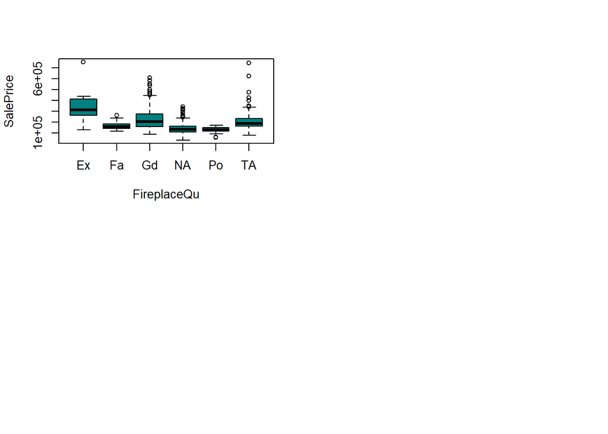

4. GarageType, GarageFinish variables also show some association with the SalePrice. In particular, built-in and attached garage types have higher sale prices then other categories. Properties with finished and rough finished garages have higher price, on average, than those with unfinished or no garage, as shown below:

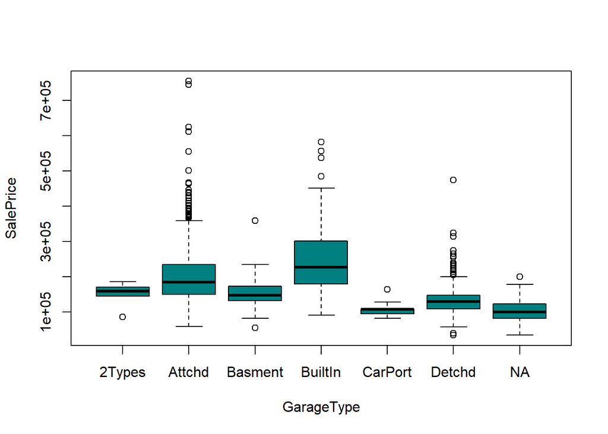

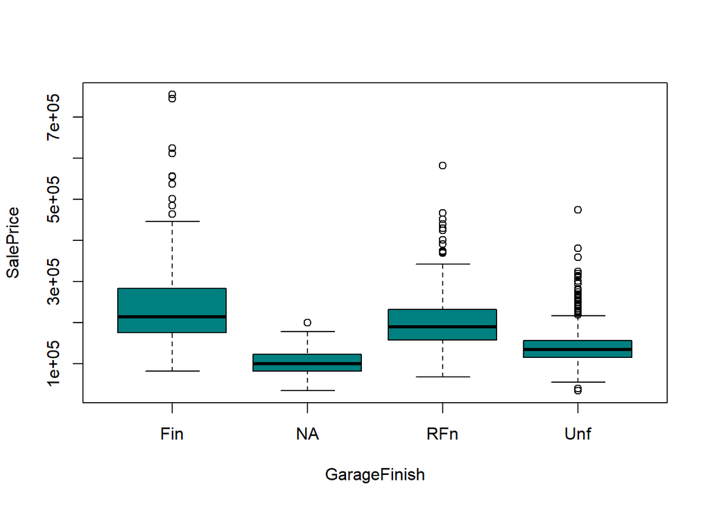

### Interesting features

1. The ExterCond variable, which is the the present condition of the material on the exterior, surprisingly, has very little correlation with the SalePrice based on the side-by-side box plot.
2. There is a very weak correlation between unfinished basement and sale proce. In general, it doesn’t seem like having a larger unfinished basement (BsmtUnfSF) results in a notably higher sale price. Interestingly, many data points bunch up around the 0 value for BsmtUnfSF, suggesting a common occurrence of properties without much unfinished space.
3. Also, there is a very weak relationship between OpenPorchSF and SalePrice, which is surprising because we would imagine that properties with greater open porch area will have higher sale price.
4. The distribution of SalePrice for properties in Ames, Iowa shows a very right-skewed shape, which implies that a significant number of houses have lower sale prices, and there are relatively fewer houses with very high sale prices. This may reflect income disparities or variations in property values within the area, with a concentration of less expensive homes and only a few high-end properties.

Graphics of the interesting features:

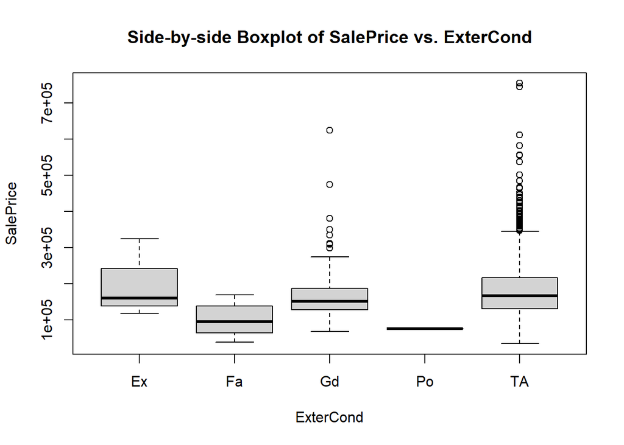

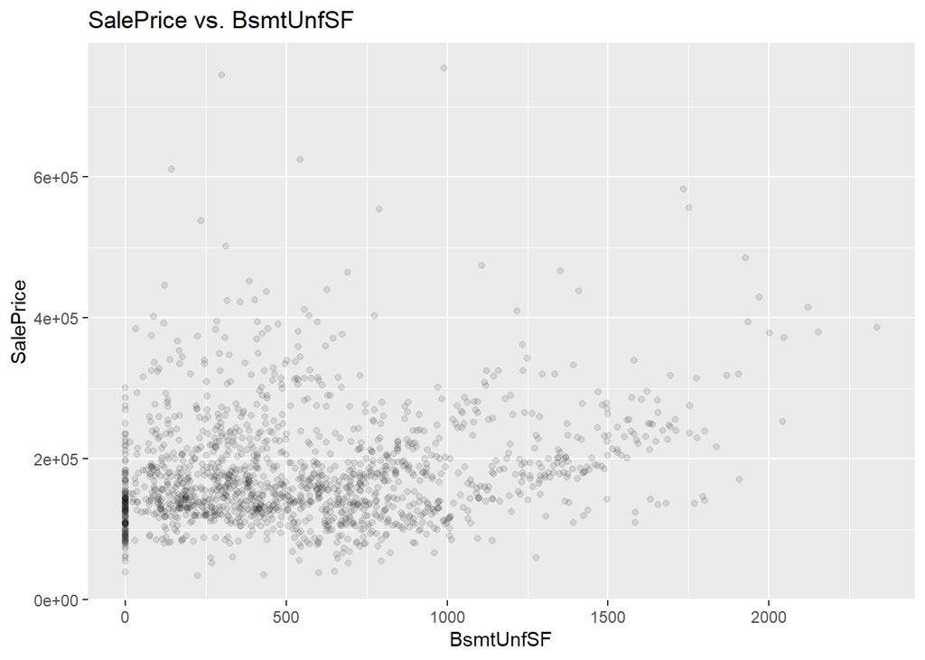

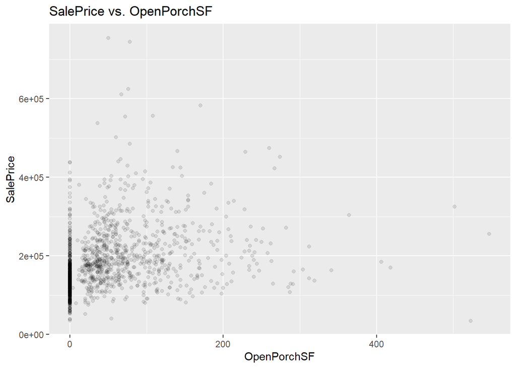

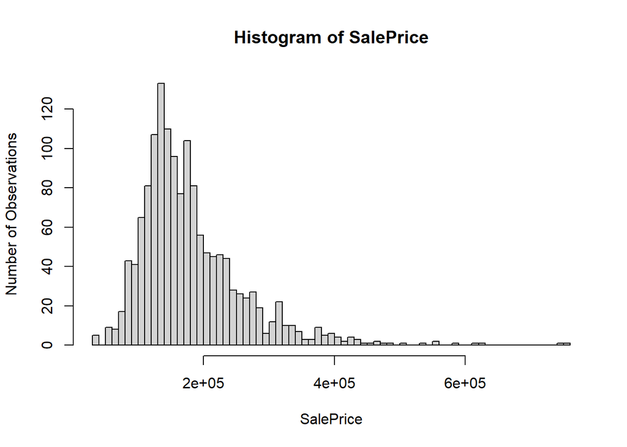